# Assignment-3-code.R

MyPC

2021-01-21

Advanced Biostatistics Practicum  
Assignment 3 report  
Student name: Nguyen The Phuong  
Student ID: 20dp005  
2020/01/10

1. Title of your statistical model for selected datasets (maximum: 30 words)  
   Title: Effect-reward imbalance at work among healthcare providers in Vietnam: A confirmatory factor analysis  
   Dataset: ERI in Vietnam (bosolieu1.dta)

```r
### Import data and select varibales
bosolieu <- read_dta("bosolieu1.dta")

# View it
names(bosolieu)
```

```
##  [1] "ma"    "a1"    "a2"    "a3"    "a4"    "a5"    "a6"    "a7"    "b1"
## [10] "b2"    "b3x1"  "b3x1k" "b3x2"  "b3x2k" "b3x3"  "b4"    "b5"    "c1"
## [19] "c2"    "c3"    "c4"    "c5"    "e1"    "e2"    "e3"    "e4"    "e5"
## [28] "e6"    "e7"    "e8"    "e9"    "e10"   "e11"   "e12"   "e13"   "e14"
## [37] "e15"   "e16"   "o1"    "o2"    "o3"    "o4"    "o5"    "o6"    "m1"
## [46] "m2"    "m3"    "m4"    "m5"    "m6"
```

2. Research hypotheses or research questions (maximum: 4 hypotheses or research questions):  
   Hypothesis: there is a relationship between the observed variables and their underlying latent constructs exists (Efforts and Rewards)
3. Description of your statistical analysis steps (maximum: 2 pages):

Step 1: Data cleaning - We need to check the items whether they need to be reverse before analysis.  
Step 2: Data processing - Rename variables  
Step 3: Check for internal consistent: Cronbach alpha.  
Step 4: Descriptive analysis: Making table 1 of general characteristics of study’s participants.  
Step 5: Factor analysis - First we will apply Exploratory Factor Analysis (EFA) to see what the data say.  
Step 6: Factor analysis - We then will use Confirmatory Factor Analysis (CFA) to confirm the theory framework of this questionnaire with the use of several models.  
Step 7: Then, apply Items response theory (IRT) to check the items.  
Step 8: Then finally apply Structural Equation Modeling (SEM) to test the relationship between ERI and other variables and latent construct (such as Loneliness).  
(Note: For this assignment, due to time limitation, I will only run to step 5).  
4. Results of the analysis with adequate interpretations (maximum: 6 pages):  
Step 1: Data cleaning  
Some items need to be reversed before doing analysis.

```r
### Select items
dat <- bosolieu
dat.ero <-  dat %>%
  dplyr::select(e1, e2, e3, e4, e5, e6,
                e7, e8, e9, e10, e11, e12, e13, e14, e15, e16,
                o1, o2, o3, o4, o5, o6)

### Check whether the variables need to reverse
alpha(dat.ero, check.keys = TRUE)
```

```
##
## Reliability analysis
## Call: alpha(x = dat.ero, check.keys = TRUE)
##
##   raw_alpha std.alpha G6(smc) average_r S/N   ase mean   sd median_r
##        0.8      0.81    0.87      0.17 4.4 0.022    3 0.24     0.16
##
##  lower alpha upper     95% confidence boundaries
## 0.76 0.8 0.85
##
##  Reliability if an item is dropped:
##      raw_alpha std.alpha G6(smc) average_r S/N alpha se var.r med.r
## e1        0.79      0.80    0.86      0.16 3.9    0.024 0.026  0.15
## e2        0.79      0.80    0.86      0.16 3.9    0.024 0.026  0.15
## e3        0.79      0.80    0.86      0.16 4.0    0.023 0.027  0.15
## e4        0.79      0.81    0.86      0.17 4.2    0.023 0.027  0.16
## e5        0.80      0.81    0.87      0.17 4.2    0.022 0.027  0.16
## e6        0.79      0.80    0.86      0.16 4.0    0.024 0.026  0.15
## e7        0.79      0.80    0.85      0.16 3.9    0.024 0.026  0.15
## e8        0.79      0.80    0.86      0.16 4.0    0.023 0.027  0.15
## e9-       0.81      0.82    0.87      0.18 4.5    0.021 0.026  0.17
## e10-      0.80      0.81    0.87      0.17 4.4    0.022 0.027  0.16
## e11-      0.80      0.81    0.86      0.17 4.2    0.022 0.027  0.16
## e12-      0.80      0.81    0.87      0.17 4.3    0.022 0.026  0.16
## e13       0.80      0.81    0.87      0.17 4.4    0.022 0.028  0.17
## e14       0.79      0.80    0.86      0.16 4.0    0.023 0.026  0.15
## e15       0.79      0.80    0.86      0.16 4.1    0.023 0.027  0.15
## e16       0.80      0.81    0.86      0.17 4.2    0.022 0.027  0.16
## o1        0.78      0.80    0.86      0.16 3.9    0.024 0.027  0.14
## o2        0.79      0.80    0.86      0.16 4.1    0.023 0.027  0.15
## o3-       0.82      0.82    0.88      0.18 4.7    0.020 0.026  0.17
## o4        0.80      0.82    0.87      0.18 4.5    0.022 0.026  0.16
## o5        0.80      0.82    0.87      0.17 4.4    0.021 0.026  0.17
## o6        0.80      0.81    0.87      0.17 4.3    0.022 0.027  0.16
##
##  Item statistics
##        n raw.r std.r r.cor r.drop mean   sd
## e1   172  0.64  0.64 0.640  0.578  3.4 0.49
## e2   172  0.62  0.63 0.622  0.561  3.3 0.51
## e3   172  0.56  0.56 0.541  0.479  3.5 0.55
```

[output cut: 29 more lines]

```
## e8  0.00 0.03 0.73 0.24    0
## e9  0.21 0.67 0.10 0.02    0
## e10 0.06 0.62 0.30 0.01    0
## e11 0.11 0.76 0.12 0.01    0
## e12 0.09 0.73 0.19 0.00    0
## e13 0.00 0.10 0.81 0.08    0
## e14 0.01 0.10 0.77 0.13    0
## e15 0.01 0.22 0.73 0.05    0
## e16 0.01 0.20 0.73 0.06    0
## o1  0.00 0.00 0.68 0.32    0
## o2  0.00 0.27 0.59 0.14    0
## o3  0.03 0.40 0.51 0.06    0
## o4  0.01 0.45 0.53 0.02    0
## o5  0.05 0.56 0.36 0.02    0
## o6  0.01 0.19 0.70 0.10    0
```

We can see that some items need to be reverse: e9, e10, e11, e12, o3

```r
### Reserve the score (e)
dat[, paste0("e", c(9, 10, 11, 12))] <- 5 -
  dat[, paste0("e", c(9, 10, 11, 12))]
dat$o3 <- 5 - dat$o3

### Save dat (reserved)
dat.rs <- dat
save(dat.rs, file = "dat.rs.Rdata")
```

Then the dataset ‘dat.rs’ is ready for cfa  
Step 2: Data processing

```r
load("dat.rs.Rdata")

### Create dat.new and renames variables
# Renames
dat.new <- dat.rs %>%
  rename("case.id" = "ma", "gender" = "a1", "age" = "a2",
         "mari.statu" = "a3", "edu.level" = "a4", "main.earn" = "a5",
         "income" = "a6", "occupation" = "a7",
         "year.work" = "b1", "hour.work" = "b2", "duty.hour.n" = "b3x1k",
         "duty.hour.d" = "b3x2k", "main.posi" = "b5",
         "sick.last.mth" = "c1", "day.sickleave" = "c3",
         "self.evaluate" = "c4", "job.satis" = "c5") %>%
  mutate(age.group = cut(age, breaks = c(-1, 24, 34, 44, 100)),
         age.group = fct_recode(age.group,
                                "1" = "(-1,24]", "2" = "(24,34]",
                                "3" = "(34,44]", "4" = "(44,100]")) %>%
  mutate(effort = e1 + e2 + e3 + e4 + e5 + e6,
         reward = e7 + e8 + e9 + e10 + e11 + e12 + e13 + e14 + e15 + e16,
         over = o1 + o2 + o3 + o4 + o5 + o6,
         friend = m1 + m2 + m3 + m4 + m5 + m6,
         esteem = e7 + e8 + e9 + e14,
         promotion = e10 + e13 + e15 + e16,
         security = e11 + e12,
         er.rate = effort/reward*10/6,
         ee.rate = effort/esteem*4/6,
         ep.rate = effort/promotion*4/6,
         es.rate = effort/security*2/6) %>%
  print(dat.new)
```

```
## # A tibble: 172 x 62
##    case.id gender   age mari.statu edu.level main.earn income occupation
##      <dbl>  <dbl> <dbl>      <dbl>     <dbl>     <dbl> <chr>       <dbl>
##  1       1      2    28          2         1         1 8               2
##  2       2      2    32          2         2         1 11              2
##  3       3      2    29          1         3         1 12              2
##  4       4      2    29          2         1         2 12              2
##  5       5      2    31          2         1         1 15              2
##  6       6      2    31          2         1         1 10              2
##  7       7      2    24          1         3         2 9               2
##  8       8      2    28          2         1         2 10              2
##  9       9      2    25          2         3         2 10              2
## 10      10      2    30          2         3         1 15              1
## # ... with 162 more rows, and 54 more variables: year.work <dbl>,
## #   hour.work <dbl>, b3x1 <dbl>, duty.hour.n <dbl>, b3x2 <dbl>,
## #   duty.hour.d <dbl>, b3x3 <dbl>, b4 <dbl>, main.posi <dbl>,
## #   sick.last.mth <dbl>, c2 <chr>, day.sickleave <chr>, self.evaluate <dbl>,
## #   job.satis <dbl>, e1 <dbl>, e2 <dbl>, e3 <dbl>, e4 <dbl>, e5 <dbl>,
## #   e6 <dbl>, e7 <dbl>, e8 <dbl>, e9 <dbl>, e10 <dbl>, e11 <dbl>, e12 <dbl>,
## #   e13 <dbl>, e14 <dbl>, e15 <dbl>, e16 <dbl>, o1 <dbl>, o2 <dbl>, o3 <dbl>,
## #   o4 <dbl>, o5 <dbl>, o6 <dbl>, m1 <dbl>, m2 <dbl>, m3 <dbl>, m4 <dbl>,
## #   m5 <dbl>, m6 <dbl>, age.group <fct>, effort <dbl>, reward <dbl>,
## #   over <dbl>, friend <dbl>, esteem <dbl>, promotion <dbl>, security <dbl>,
## #   er.rate <dbl>, ee.rate <dbl>, ep.rate <dbl>, es.rate <dbl>
```

```r
# Change factors
dat <- dat.new %>%
  mutate(
    ERI = er.rate > 1,
    EEI = ee.rate > 1,
    EPI = ep.rate > 1,
    ESI = es.rate > 1,
    ER.high = er.rate > median(er.rate),
    EE.high = ee.rate > median(ee.rate),
    EP.high = ep.rate > median(ep.rate),
    ES.high = es.rate > median(es.rate),
    direct.p = main.posi == 2,
    Gender = as.factor(gender),
    Gender = factor(Gender,
                    labels = c("Male", "Female")),

    job.dissatis = job.satis == 2,
    young = age < 28,
    poor.self.rate = self.evaluate == 1,
    iso.group = cut(friend, breaks = c(-1, 15, 19, 100)),
    iso.group = fct_recode(iso.group,
                           "isolate" = "(-1,15]", "normal" = "(15,19]",
                           "friendly" = "(19,100]"),
    over.work = hour.work > 50,
    live.spouse = mari.statu == 2,
    Income = as.numeric(income),
    income.low = income < median(income),
    Education = factor(edu.level),
    # edu.inter = edu.level == 1,
    # edu.college = edu.level == 2,
    # edu.uni = edu.level == 3,
    duty.hour.n = ifelse(is.na(duty.hour.n), 0, duty.hour.n),
    duty.hour.d = ifelse(is.na(duty.hour.d), 0, duty.hour.d),
    Breadwinner = as.factor(main.earn),
    Breadwinner = factor(Breadwinner, labels = c("Yes", "No")),
    Married_status = as.factor(mari.statu),
    Married_status = factor(Married_status,
                            labels = c("Married", "Not married")),
    Age = as.numeric(age),
    Position = as.factor(main.posi),
    Position = factor(Position,
                       labels = c("Manager", "Clinician", "Other"))
  )
# Check names
names(dat.new)
```

```
##  [1] "case.id"       "gender"        "age"           "mari.statu"
##  [5] "edu.level"     "main.earn"     "income"        "occupation"
##  [9] "year.work"     "hour.work"     "b3x1"          "duty.hour.n"
## [13] "b3x2"          "duty.hour.d"   "b3x3"          "b4"
## [17] "main.posi"     "sick.last.mth" "c2"            "day.sickleave"
## [21] "self.evaluate" "job.satis"     "e1"            "e2"
## [25] "e3"            "e4"            "e5"            "e6"
## [29] "e7"            "e8"            "e9"            "e10"
## [33] "e11"           "e12"           "e13"           "e14"
## [37] "e15"           "e16"           "o1"            "o2"
## [41] "o3"            "o4"            "o5"            "o6"
## [45] "m1"            "m2"            "m3"            "m4"
## [49] "m5"            "m6"            "age.group"     "effort"
## [53] "reward"        "over"          "friend"        "esteem"
## [57] "promotion"     "security"      "er.rate"       "ee.rate"
## [61] "ep.rate"       "es.rate"
```

```r
# Save dat.new
dat.new <- dat
save(dat.new, file = "dat.new.Rdata")


 #' Step 3: Checking for internal consistent: Cronbach alpha
 #'

# Load data
load("dat.new.Rdata")

# For effort questions
dat.effort <- dat.new %>%
  dplyr::select(e1, e2, e3, e4, e5, e6)
a.effort <- alpha(dat.effort)
a.effort
```

```
##
## Reliability analysis
## Call: alpha(x = dat.effort)
##
##   raw_alpha std.alpha G6(smc) average_r S/N   ase mean  sd median_r
##        0.8       0.8    0.79      0.41 4.1 0.024  3.3 0.4     0.41
##
##  lower alpha upper     95% confidence boundaries
## 0.75 0.8 0.84
##
##  Reliability if an item is dropped:
##    raw_alpha std.alpha G6(smc) average_r S/N alpha se  var.r med.r
## e1      0.75      0.75    0.73      0.38 3.0    0.030 0.0099  0.39
## e2      0.77      0.78    0.76      0.41 3.5    0.028 0.0094  0.42
## e3      0.77      0.77    0.76      0.41 3.4    0.028 0.0127  0.39
## e4      0.77      0.77    0.76      0.41 3.4    0.029 0.0148  0.42
## e5      0.80      0.80    0.78      0.45 4.1    0.024 0.0055  0.45
## e6      0.74      0.75    0.73      0.38 3.1    0.031 0.0132  0.36
##
##  Item statistics
##      n raw.r std.r r.cor r.drop mean   sd
## e1 172  0.75  0.77  0.73   0.64  3.4 0.49
## e2 172  0.68  0.70  0.62   0.53  3.3 0.51
## e3 172  0.70  0.71  0.63   0.55  3.5 0.55
## e4 172  0.72  0.70  0.62   0.55  3.1 0.62
## e5 172  0.63  0.60  0.48   0.42  3.1 0.63
## e6 172  0.78  0.77  0.72   0.65  3.3 0.57
##
## Non missing response frequency for each item
##       1    2    3    4 miss
## e1 0.00 0.00 0.62 0.38    0
## e2 0.01 0.02 0.69 0.28    0
## e3 0.01 0.01 0.49 0.50    0
## e4 0.01 0.13 0.62 0.24    0
## e5 0.02 0.10 0.65 0.24    0
## e6 0.01 0.02 0.62 0.35    0
```

```r
# For reward questions
dat.reward <- dat.new %>%
  dplyr::select(e7, e8, e9, e10, e11, e12, e13, e14, e15, e16 )
a.reward <- alpha(dat.reward)
a.reward
```

```
##
## Reliability analysis
## Call: alpha(x = dat.reward)
##
##   raw_alpha std.alpha G6(smc) average_r S/N   ase mean   sd median_r
##       0.76      0.76    0.79      0.24 3.2 0.028    3 0.29     0.23
##
##  lower alpha upper     95% confidence boundaries
## 0.7 0.76 0.81
##
##  Reliability if an item is dropped:
##     raw_alpha std.alpha G6(smc) average_r S/N alpha se var.r med.r
## e7       0.72      0.72    0.75      0.22 2.6    0.032 0.024  0.22
## e8       0.72      0.73    0.76      0.23 2.7    0.032 0.026  0.22
## e9       0.75      0.76    0.78      0.26 3.1    0.028 0.021  0.24
## e10      0.74      0.75    0.77      0.25 2.9    0.030 0.024  0.24
## e11      0.74      0.74    0.77      0.24 2.9    0.030 0.026  0.22
## e12      0.73      0.74    0.77      0.24 2.8    0.031 0.025  0.22
## e13      0.76      0.77    0.80      0.27 3.4    0.027 0.020  0.25
## e14      0.71      0.71    0.74      0.21 2.4    0.033 0.022  0.22
## e15      0.74      0.74    0.77      0.24 2.9    0.030 0.022  0.23
## e16      0.74      0.74    0.77      0.24 2.8    0.030 0.024  0.23
##
##  Item statistics
##       n raw.r std.r r.cor r.drop mean   sd
## e7  172  0.64  0.66  0.63   0.53  3.1 0.46
## e8  172  0.62  0.64  0.59   0.50  3.2 0.48
## e9  172  0.50  0.45  0.37   0.31  3.1 0.62
## e10 172  0.56  0.52  0.45   0.39  2.7 0.59
## e11 172  0.56  0.56  0.48   0.42  3.0 0.52
## e12 172  0.59  0.58  0.51   0.46  2.9 0.51
## e13 172  0.32  0.36  0.23   0.17  3.0 0.43
## e14 172  0.72  0.74  0.72   0.62  3.0 0.50
## e15 172  0.54  0.56  0.50   0.40  2.8 0.51
## e16 172  0.56  0.57  0.51   0.42  2.8 0.53
##
## Non missing response frequency for each item
##        1    2    3    4 miss
## e7  0.00 0.05 0.77 0.19    0
## e8  0.00 0.03 0.73 0.24    0
## e9  0.02 0.10 0.67 0.21    0
## e10 0.01 0.30 0.62 0.06    0
## e11 0.01 0.12 0.76 0.11    0
## e12 0.00 0.19 0.73 0.09    0
## e13 0.00 0.10 0.81 0.08    0
## e14 0.01 0.10 0.77 0.13    0
## e15 0.01 0.22 0.73 0.05    0
## e16 0.01 0.20 0.73 0.06    0
```

```r
# For over commitment questions
dat.over <- dat.new %>%
  dplyr::select(o1, o2, o3, o4, o5, o6)
a.over <- alpha(dat.over)
a.over
```

```
##
## Reliability analysis
## Call: alpha(x = dat.over)
##
##   raw_alpha std.alpha G6(smc) average_r S/N   ase mean   sd median_r
##       0.67      0.68    0.67      0.26 2.1 0.038  2.7 0.36      0.3
##
##  lower alpha upper     95% confidence boundaries
## 0.6 0.67 0.75
##
##  Reliability if an item is dropped:
##    raw_alpha std.alpha G6(smc) average_r S/N alpha se var.r med.r
## o1      0.63      0.64    0.62      0.26 1.8    0.044 0.021  0.31
## o2      0.60      0.61    0.58      0.24 1.5    0.048 0.018  0.26
## o3      0.72      0.72    0.68      0.34 2.6    0.033 0.004  0.33
## o4      0.64      0.65    0.63      0.27 1.9    0.043 0.019  0.28
## o5      0.58      0.60    0.58      0.23 1.5    0.050 0.025  0.28
## o6      0.59      0.60    0.58      0.23 1.5    0.049 0.024  0.26
##
##  Item statistics
##      n raw.r std.r r.cor r.drop mean   sd
## o1 172  0.58  0.62  0.50   0.41  3.3 0.47
## o2 172  0.69  0.69  0.62   0.49  2.9 0.63
## o3 172  0.45  0.41  0.21   0.16  2.4 0.65
## o4 172  0.57  0.59  0.46   0.37  2.6 0.54
## o5 172  0.72  0.70  0.63   0.53  2.4 0.62
## o6 172  0.70  0.70  0.62   0.53  2.9 0.57
##
## Non missing response frequency for each item
##       1    2    3    4 miss
## o1 0.00 0.00 0.68 0.32    0
## o2 0.00 0.27 0.59 0.14    0
## o3 0.06 0.51 0.40 0.03    0
## o4 0.01 0.45 0.53 0.02    0
## o5 0.05 0.56 0.36 0.02    0
## o6 0.01 0.19 0.70 0.10    0
```

```r
# Produce table of item statistics
it.e <- a.effort$item.stats %>%
  rownames_to_column()
it.r <- a.reward$item.stats %>%
  rownames_to_column()
it.o <- a.over$item.stats %>%
  rownames_to_column()

item <- rbind(it.e, it.r, it.o) %>%
  format(digits=2, nsmall=2) %>%
  # dplyr::rename(Items=rowname, N=n, raw.r)
  qflextable()
```

Step 4: Descriptive analysis: Table 1.

```r
load("dat.new.Rdata")

# Tab1: General characteristics of participants
```

```r
factor1 <- c("Gender", "Education", "Married_status", "Breadwinner",
             "Position")

var1 <- c("Age", "Gender", "Education", "Married_status", "Income",
          "Breadwinner", "Position")

tab1 <- CreateTableOne(vars = var1, data = dat.new, factorVars = factor1)
tab1 <- print(tab1, showAllLevels = TRUE)


# Tab1s: Stratify by sex
```

```r
tab1s <- CreateTableOne(vars = var1, data = dat.new, factorVars = factor1,
                        strata = c("Gender"))
tab1s <- print(tab1s, showAllLevels = TRUE)


# Combine Table 1
```

```r
table1 <- cbind(tab1, tab1s[,2:4])

# Make a nice table
table1p <- table1 %>%
  as.data.frame() %>%
  rownames_to_column(var = "Variables")

l <- c("X", paste0("X.", 1:90))
table1p$Variables[table1p$Variables %in% l] <- ""

table1f <-  qflextable(table1p) %>%
  set_table_properties(width=0.5, layout = "autofit") %>%
  add_header(Variables = "Variables", level = "level", Overall = "Overall",
             Male="Gender", Female="Gender", p = "Gender",
             top = TRUE ) %>%
  merge_h(part = "header") %>%
  merge_v(part = "header") %>%
  theme_booktabs() %>%
  align_text_col(align = "center") %>%
  flextable::align(align = "left", j=c("Variables", "level")) %>%
  line_spacing(space = 1) %>%
  fontsize(size = 12) %>%
  flextable::bold(part = "header") %>%
  flextable::width(j = c("Male", "Female", "p"), width = 3)
```

Table 1: General characteristics of participants.

| Variables | level | Overall | Gender Male | Gender Female | Gender p |
| --- | --- | --- | --- | --- | --- |
| n |  | 172 | 46 | 126 |  |
| Age..mean..SD.. |  | 28.51 (3.99) | 28.74 (4.22) | 28.43 (3.92) | 0.653 |
| Gender.... | Male | 46 (26.7) | 46 (100.0) | 0 ( 0.0) | <0.001 |
|  | Female | 126 (73.3) | 0 ( 0.0) | 126 (100.0) |  |
| Education.... | 1 | 80 (46.5) | 21 ( 45.7) | 59 ( 46.8) | 0.980 |
|  | 2 | 32 (18.6) | 9 ( 19.6) | 23 ( 18.3) |  |
|  | 3 | 60 (34.9) | 16 ( 34.8) | 44 ( 34.9) |  |
| Married_status.... | Married | 48 (27.9) | 15 ( 32.6) | 33 ( 26.2) | 0.523 |
|  | Not married | 124 (72.1) | 31 ( 67.4) | 93 ( 73.8) |  |
| Income..mean..SD.. |  | 11.22 (3.15) | 11.57 (3.61) | 11.09 (2.97) | 0.384 |
| Breadwinner.... | Yes | 106 (61.6) | 34 ( 73.9) | 72 ( 57.1) | 0.068 |
|  | No | 66 (38.4) | 12 ( 26.1) | 54 ( 42.9) |  |
| Position.... | Manager | 15 ( 8.8) | 7 ( 15.2) | 8 ( 6.5) | 0.143 |
|  | Clinician | 119 (70.0) | 28 ( 60.9) | 91 ( 73.4) |  |
|  | Other | 36 (21.2) | 11 ( 23.9) | 25 ( 20.2) |  |

Step 5: Exploratory Factor Analysis.

```r
# Prepare data contain items only
dat.ero <- dat.new %>%
dplyr::select(e1, e2, e3, e4, e5, e6,
              e7, e8, e9, e10, e11, e12, e13, e14, e15, e16,
              o1, o2, o3, o4, o5, o6) %>%
  as.matrix()


### Produce TABLE S1 - Correlation matrix of all items ERI
### First, check the correaltion matrix of all dataset
# Pearson correlation
cor.mat.p.ero <- round(cor(dat.ero, method = c("pearson")),2)
cor.mat.p.ero
```

```
##       e1   e2    e3    e4    e5    e6    e7    e8    e9   e10   e11   e12   e13
## e1  1.00 0.57  0.50  0.37  0.33  0.53  0.39  0.34  0.07  0.12  0.20  0.06  0.07
## e2  0.57 1.00  0.43  0.36  0.21  0.41  0.44  0.43  0.15  0.13  0.25  0.12  0.08
## e3  0.50 0.43  1.00  0.47  0.24  0.37  0.33  0.22  0.06 -0.04  0.23  0.03  0.12
## e4  0.37 0.36  0.47  1.00  0.31  0.49  0.05  0.08  0.04  0.03  0.06  0.09 -0.01
## e5  0.33 0.21  0.24  0.31  1.00  0.48  0.31  0.12 -0.02  0.06  0.10  0.12  0.07
## e6  0.53 0.41  0.37  0.49  0.48  1.00  0.33  0.24  0.12  0.10  0.21  0.09 -0.02
## e7  0.39 0.44  0.33  0.05  0.31  0.33  1.00  0.55  0.23  0.20  0.31  0.18  0.22
## e8  0.34 0.43  0.22  0.08  0.12  0.24  0.55  1.00  0.23  0.21  0.25  0.25  0.16
## e9  0.07 0.15  0.06  0.04 -0.02  0.12  0.23  0.23  1.00  0.45  0.15  0.37 -0.13
## e10 0.12 0.13 -0.04  0.03  0.06  0.10  0.20  0.21  0.45  1.00  0.34  0.40 -0.02
## e11 0.20 0.25  0.23  0.06  0.10  0.21  0.31  0.25  0.15  0.34  1.00  0.40  0.07
## e12 0.06 0.12  0.03  0.09  0.12  0.09  0.18  0.25  0.37  0.40  0.40  1.00 -0.01
## e13 0.07 0.08  0.12 -0.01  0.07 -0.02  0.22  0.16 -0.13 -0.02  0.07 -0.01  1.00
## e14 0.21 0.28  0.29  0.03  0.18  0.15  0.49  0.40  0.17  0.17  0.36  0.28  0.33
## e15 0.31 0.28  0.24  0.19  0.20  0.19  0.33  0.29  0.00  0.08  0.09  0.13  0.22
## e16 0.15 0.11  0.11  0.03  0.19  0.09  0.21  0.25  0.07  0.11  0.15  0.24  0.16
## o1  0.44 0.39  0.29  0.31  0.20  0.42  0.44  0.33  0.12  0.09  0.16  0.16  0.12
## o2  0.20 0.27  0.29  0.17  0.08  0.26  0.28  0.22 -0.10  0.02  0.18  0.00  0.25
## o3  0.04 0.02  0.06  0.10 -0.09 -0.12 -0.01 -0.02 -0.01 -0.11 -0.07  0.03  0.08
## o4  0.17 0.18  0.03  0.26  0.05  0.26  0.01 -0.03 -0.13  0.02 -0.11 -0.20 -0.02
## o5  0.12 0.04  0.04  0.12 -0.02  0.15  0.13  0.07 -0.22 -0.11 -0.06 -0.20  0.10
## o6  0.19 0.14  0.19  0.07 -0.02  0.07  0.06  0.06 -0.11  0.04  0.07 -0.08  0.16
##       e14   e15   e16   o1    o2    o3    o4    o5    o6
## e1   0.21  0.31  0.15 0.44  0.20  0.04  0.17  0.12  0.19
## e2   0.28  0.28  0.11 0.39  0.27  0.02  0.18  0.04  0.14
## e3   0.29  0.24  0.11 0.29  0.29  0.06  0.03  0.04  0.19
## e4   0.03  0.19  0.03 0.31  0.17  0.10  0.26  0.12  0.07
## e5   0.18  0.20  0.19 0.20  0.08 -0.09  0.05 -0.02 -0.02
## e6   0.15  0.19  0.09 0.42  0.26 -0.12  0.26  0.15  0.07
## e7   0.49  0.33  0.21 0.44  0.28 -0.01  0.01  0.13  0.06
## e8   0.40  0.29  0.25 0.33  0.22 -0.02 -0.03  0.07  0.06
## e9   0.17  0.00  0.07 0.12 -0.10 -0.01 -0.13 -0.22 -0.11
## e10  0.17  0.08  0.11 0.09  0.02 -0.11  0.02 -0.11  0.04
## e11  0.36  0.09  0.15 0.16  0.18 -0.07 -0.11 -0.06  0.07
## e12  0.28  0.13  0.24 0.16  0.00  0.03 -0.20 -0.20 -0.08
## e13  0.33  0.22  0.16 0.12  0.25  0.08 -0.02  0.10  0.16
## e14  1.00  0.47  0.48 0.35  0.25 -0.11 -0.08 -0.04  0.01
## e15  0.47  1.00  0.52 0.26  0.22  0.04  0.08  0.14 -0.01
## e16  0.48  0.52  1.00 0.17  0.20 -0.06 -0.05  0.03  0.00
## o1   0.35  0.26  0.17 1.00  0.44  0.04  0.26  0.25  0.31
## o2   0.25  0.22  0.20 0.44  1.00  0.06  0.32  0.36  0.38
## o3  -0.11  0.04 -0.06 0.04  0.06  1.00 -0.03  0.24  0.22
## o4  -0.08  0.08 -0.05 0.26  0.32 -0.03  1.00  0.35  0.30
## o5  -0.04  0.14  0.03 0.25  0.36  0.24  0.35  1.00  0.41
## o6   0.01 -0.01  0.00 0.31  0.38  0.22  0.30  0.41  1.00
```

```r
# Spearman for non-symmatric data
cor.mat.s.ero <- round(cor(dat.ero, method = c("spearman")),2)
cor.mat.s.ero
```

```
##       e1   e2   e3   e4    e5    e6    e7    e8    e9   e10   e11   e12   e13
## e1  1.00 0.60 0.52 0.38  0.35  0.56  0.39  0.35  0.09  0.13  0.20  0.04  0.07
## e2  0.60 1.00 0.48 0.39  0.23  0.46  0.44  0.42  0.12  0.14  0.23  0.09  0.05
## e3  0.52 0.48 1.00 0.46  0.23  0.45  0.36  0.25  0.11  0.01  0.26  0.07  0.13
## e4  0.38 0.39 0.46 1.00  0.30  0.50  0.08  0.10  0.05  0.05  0.07  0.11  0.00
## e5  0.35 0.23 0.23 0.30  1.00  0.42  0.38  0.18  0.02  0.11  0.12  0.15  0.13
## e6  0.56 0.46 0.45 0.50  0.42  1.00  0.41  0.32  0.16  0.13  0.21  0.09  0.05
## e7  0.39 0.44 0.36 0.08  0.38  0.41  1.00  0.57  0.26  0.21  0.32  0.17  0.22
## e8  0.35 0.42 0.25 0.10  0.18  0.32  0.57  1.00  0.26  0.22  0.27  0.23  0.17
## e9  0.09 0.12 0.11 0.05  0.02  0.16  0.26  0.26  1.00  0.39  0.19  0.39 -0.11
## e10 0.13 0.14 0.01 0.05  0.11  0.13  0.21  0.22  0.39  1.00  0.36  0.39  0.00
## e11 0.20 0.23 0.26 0.07  0.12  0.21  0.32  0.27  0.19  0.36  1.00  0.39  0.10
## e12 0.04 0.09 0.07 0.11  0.15  0.09  0.17  0.23  0.39  0.39  0.39  1.00 -0.02
## e13 0.07 0.05 0.13 0.00  0.13  0.05  0.22  0.17 -0.11  0.00  0.10 -0.02  1.00
## e14 0.21 0.27 0.32 0.05  0.25  0.24  0.52  0.42  0.21  0.22  0.35  0.29  0.31
## e15 0.31 0.28 0.22 0.19  0.20  0.22  0.32  0.27  0.03  0.13  0.08  0.14  0.19
## e16 0.15 0.12 0.11 0.04  0.20  0.13  0.21  0.26  0.13  0.15  0.17  0.25  0.14
## o1  0.44 0.40 0.30 0.34  0.25  0.51  0.45  0.34  0.16  0.10  0.15  0.15  0.12
## o2  0.20 0.28 0.30 0.16  0.12  0.35  0.28  0.24 -0.07  0.02  0.17 -0.01  0.24
## o3  0.05 0.04 0.08 0.14 -0.02 -0.03 -0.02 -0.02 -0.02 -0.11 -0.07  0.04  0.07
## o4  0.17 0.19 0.06 0.27  0.05  0.25  0.01 -0.05 -0.16  0.01 -0.12 -0.21 -0.02
## o5  0.12 0.09 0.06 0.13 -0.01  0.21  0.17  0.10 -0.22 -0.10 -0.06 -0.20  0.08
## o6  0.19 0.15 0.21 0.08  0.03  0.16  0.05  0.07 -0.10  0.01  0.08 -0.06  0.16
##       e14  e15   e16   o1    o2    o3    o4    o5    o6
## e1   0.21 0.31  0.15 0.44  0.20  0.05  0.17  0.12  0.19
## e2   0.27 0.28  0.12 0.40  0.28  0.04  0.19  0.09  0.15
## e3   0.32 0.22  0.11 0.30  0.30  0.08  0.06  0.06  0.21
## e4   0.05 0.19  0.04 0.34  0.16  0.14  0.27  0.13  0.08
## e5   0.25 0.20  0.20 0.25  0.12 -0.02  0.05 -0.01  0.03
## e6   0.24 0.22  0.13 0.51  0.35 -0.03  0.25  0.21  0.16
## e7   0.52 0.32  0.21 0.45  0.28 -0.02  0.01  0.17  0.05
## e8   0.42 0.27  0.26 0.34  0.24 -0.02 -0.05  0.10  0.07
## e9   0.21 0.03  0.13 0.16 -0.07 -0.02 -0.16 -0.22 -0.10
## e10  0.22 0.13  0.15 0.10  0.02 -0.11  0.01 -0.10  0.01
## e11  0.35 0.08  0.17 0.15  0.17 -0.07 -0.12 -0.06  0.08
## e12  0.29 0.14  0.25 0.15 -0.01  0.04 -0.21 -0.20 -0.06
## e13  0.31 0.19  0.14 0.12  0.24  0.07 -0.02  0.08  0.16
## e14  1.00 0.42  0.43 0.36  0.25 -0.12 -0.08 -0.02  0.01
## e15  0.42 1.00  0.50 0.25  0.20  0.08  0.08  0.15  0.00
## e16  0.43 0.50  1.00 0.18  0.20 -0.05 -0.02  0.04  0.01
## o1   0.36 0.25  0.18 1.00  0.42  0.05  0.25  0.25  0.31
## o2   0.25 0.20  0.20 0.42  1.00  0.05  0.32  0.37  0.38
## o3  -0.12 0.08 -0.05 0.05  0.05  1.00  0.01  0.24  0.23
## o4  -0.08 0.08 -0.02 0.25  0.32  0.01  1.00  0.34  0.27
## o5  -0.02 0.15  0.04 0.25  0.37  0.24  0.34  1.00  0.38
## o6   0.01 0.00  0.01 0.31  0.38  0.23  0.27  0.38  1.00
```

```r
# Kendall for non-symmatric data
cor.mat.k.ero <- round(cor(dat.ero, method = c("kendall")),2)
cor.mat.k.ero
```

```
##       e1   e2   e3   e4    e5    e6    e7    e8    e9   e10   e11   e12   e13
## e1  1.00 0.60 0.51 0.37  0.34  0.55  0.38  0.35  0.09  0.13  0.19  0.04  0.07
## e2  0.60 1.00 0.47 0.37  0.22  0.45  0.43  0.42  0.12  0.13  0.22  0.09  0.05
## e3  0.51 0.47 1.00 0.44  0.22  0.44  0.35  0.24  0.11  0.01  0.25  0.07  0.13
## e4  0.37 0.37 0.44 1.00  0.28  0.48  0.07  0.09  0.05  0.05  0.07  0.10  0.00
## e5  0.34 0.22 0.22 0.28  1.00  0.41  0.36  0.17  0.01  0.10  0.11  0.14  0.12
## e6  0.55 0.45 0.44 0.48  0.41  1.00  0.40  0.31  0.15  0.13  0.20  0.08  0.05
## e7  0.38 0.43 0.35 0.07  0.36  0.40  1.00  0.56  0.25  0.20  0.31  0.17  0.21
## e8  0.35 0.42 0.24 0.09  0.17  0.31  0.56  1.00  0.25  0.21  0.25  0.22  0.17
## e9  0.09 0.12 0.11 0.05  0.01  0.15  0.25  0.25  1.00  0.37  0.18  0.37 -0.11
## e10 0.13 0.13 0.01 0.05  0.10  0.13  0.20  0.21  0.37  1.00  0.35  0.38  0.00
## e11 0.19 0.22 0.25 0.07  0.11  0.20  0.31  0.25  0.18  0.35  1.00  0.37  0.10
## e12 0.04 0.09 0.07 0.10  0.14  0.08  0.17  0.22  0.37  0.38  0.37  1.00 -0.02
## e13 0.07 0.05 0.13 0.00  0.12  0.05  0.21  0.17 -0.11  0.00  0.10 -0.02  1.00
## e14 0.21 0.26 0.31 0.05  0.23  0.23  0.50  0.40  0.19  0.21  0.34  0.27  0.30
## e15 0.30 0.27 0.22 0.18  0.19  0.21  0.31  0.27  0.03  0.13  0.07  0.13  0.18
## e16 0.15 0.12 0.10 0.04  0.18  0.12  0.20  0.25  0.12  0.14  0.16  0.24  0.13
## o1  0.44 0.40 0.30 0.32  0.24  0.50  0.44  0.33  0.16  0.10  0.15  0.15  0.12
## o2  0.19 0.27 0.29 0.15  0.11  0.33  0.27  0.22 -0.06  0.02  0.16 -0.01  0.23
## o3  0.05 0.04 0.08 0.13 -0.02 -0.03 -0.02 -0.01 -0.02 -0.11 -0.06  0.03  0.07
## o4  0.16 0.19 0.06 0.26  0.05  0.25  0.01 -0.05 -0.15  0.01 -0.12 -0.20 -0.02
## o5  0.12 0.09 0.05 0.12 -0.01  0.20  0.16  0.09 -0.21 -0.09 -0.06 -0.19  0.08
## o6  0.19 0.14 0.20 0.07  0.02  0.15  0.05  0.07 -0.10  0.01  0.07 -0.06  0.15
##       e14  e15   e16   o1    o2    o3    o4    o5    o6
## e1   0.21 0.30  0.15 0.44  0.19  0.05  0.16  0.12  0.19
## e2   0.26 0.27  0.12 0.40  0.27  0.04  0.19  0.09  0.14
## e3   0.31 0.22  0.10 0.30  0.29  0.08  0.06  0.05  0.20
## e4   0.05 0.18  0.04 0.32  0.15  0.13  0.26  0.12  0.07
## e5   0.23 0.19  0.18 0.24  0.11 -0.02  0.05 -0.01  0.02
## e6   0.23 0.21  0.12 0.50  0.33 -0.03  0.25  0.20  0.15
## e7   0.50 0.31  0.20 0.44  0.27 -0.02  0.01  0.16  0.05
## e8   0.40 0.27  0.25 0.33  0.22 -0.01 -0.05  0.09  0.07
## e9   0.19 0.03  0.12 0.16 -0.06 -0.02 -0.15 -0.21 -0.10
## e10  0.21 0.13  0.14 0.10  0.02 -0.11  0.01 -0.09  0.01
## e11  0.34 0.07  0.16 0.15  0.16 -0.06 -0.12 -0.06  0.07
## e12  0.27 0.13  0.24 0.15 -0.01  0.03 -0.20 -0.19 -0.06
## e13  0.30 0.18  0.13 0.12  0.23  0.07 -0.02  0.08  0.15
## e14  1.00 0.41  0.41 0.35  0.23 -0.12 -0.07 -0.02  0.01
## e15  0.41 1.00  0.49 0.25  0.19  0.08  0.08  0.14  0.00
## e16  0.41 0.49  1.00 0.17  0.19 -0.04 -0.01  0.04  0.01
## o1   0.35 0.25  0.17 1.00  0.41  0.04  0.24  0.25  0.30
## o2   0.23 0.19  0.19 0.41  1.00  0.04  0.30  0.35  0.36
## o3  -0.12 0.08 -0.04 0.04  0.04  1.00  0.01  0.24  0.22
## o4  -0.07 0.08 -0.01 0.24  0.30  0.01  1.00  0.33  0.26
## o5  -0.02 0.14  0.04 0.25  0.35  0.24  0.33  1.00  0.36
## o6   0.01 0.00  0.01 0.30  0.36  0.22  0.26  0.36  1.00
```

Kendall’s Tau and Spearman’s rank correlation coefficient assess statistical associations based on the ranks of the data. Ranking data is carried out on the variables that are separately put in order and are numbered.

Kendall’s Tau: usually smaller values than Spearman’s rho correlation. Calculations based on concordant and discordant pairs. Insensitive to error. P values are more accurate with smaller sample sizes. Kendall seems to be a robust way.

However, the Factor Analysis normally use pearson correlation. Pearson also is appropriate for a large sample (>100) Since this study’s objective is not to find a suitable method We decide to use Pearson which is better fit our objective of using FA.

```r
### Combine matrix
table1s <- cor.mat.p.ero

# Delete the diagonal
diag(table1s) = ""
# Delete the upper part
table1s[upper.tri(table1s)] <- ""


### Calculate the p-value to combine the Table 1S
p.ero <- corr.test(dat.ero,
                   use = "complete",
                   method = "pearson",
                   adjust = "holm")
# We apply the adjustment for multiple tests
# See p.adjust for details about why to use "holm" rather than "bonferroni"

p.mat.p.ero <- round(p.ero$p, 3)

# Delete the diagonal
diag(p.mat.p.ero) = ""
# Replace p<0.001
p.mat.p.ero = ifelse(p.mat.p.ero==0, "<0.001", p.mat.p.ero)
# Delete the lower part
p.mat.p.ero[lower.tri(p.mat.p.ero)] <- ""

### Combine matrix
table1s[upper.tri(table1s)] <- p.mat.p.ero[upper.tri(p.mat.p.ero)]

# Produce the p-value matrix (upper triangle)
write.csv(table1s, file = "table1s.csv")

# Make a nice table
table1sf <-  table1s %>%
  as.data.frame() %>%
  qflextable() %>%
  set_table_properties(layout = "autofit") %>%
  theme_booktabs() %>%
  align_text_col(align = "center") %>%
  line_spacing(space = 1) %>%
  fontsize(size = 12) %>%
  flextable::bold(part = "header")
```

Table S1: Correlation matrix of the 22 items

```r
table1sf
```

| e1 | e2 | e3 | e4 | e5 | e6 | e7 | e8 | e9 | e10 | e11 | e12 | e13 | e14 | e15 | e16 | o1 | o2 | o3 | o4 | o5 | o6 |
| --- | --- | --- | --- | --- | --- | --- | --- | --- | --- | --- | --- | --- | --- | --- | --- | --- | --- | --- | --- | --- | --- |
|  | <0.001 | <0.001 | <0.001 | 0.002 | <0.001 | <0.001 | 0.001 | 1 | 1 | 1 | 1 | 1 | 0.726 | 0.005 | 1 | <0.001 | 1 | 1 | 1 | 1 | 1 |
| 0.57 |  | <0.001 | <0.001 | 0.923 | <0.001 | <0.001 | <0.001 | 1 | 1 | 0.183 | 1 | 1 | 0.037 | 0.029 | 1 | <0.001 | 0.059 | 1 | 1 | 1 | 1 |
| 0.5 | 0.43 |  | <0.001 | 0.21 | <0.001 | 0.001 | 0.465 | 1 | 1 | 0.315 | 1 | 1 | 0.021 | 0.233 | 1 | 0.026 | 0.02 | 1 | 1 | 1 | 1 |
| 0.37 | 0.36 | 0.47 |  | 0.005 | <0.001 | 1 | 1 | 1 | 1 | 1 | 1 | 1 | 1 | 1 | 1 | 0.008 | 1 | 1 | 0.102 | 1 | 1 |
| 0.33 | 0.21 | 0.24 | 0.31 |  | <0.001 | 0.006 | 1 | 1 | 1 | 1 | 1 | 1 | 1 | 1 | 1 | 1 | 1 | 1 | 1 | 1 | 1 |
| 0.53 | 0.41 | 0.37 | 0.49 | 0.48 |  | 0.002 | 0.233 | 1 | 1 | 0.862 | 1 | 1 | 1 | 1 | 1 | <0.001 | 0.08 | 1 | 0.119 | 1 | 1 |
| 0.39 | 0.44 | 0.33 | 0.05 | 0.31 | 0.33 |  | <0.001 | 0.34 | 1 | 0.008 | 1 | 0.532 | <0.001 | 0.002 | 0.706 | <0.001 | 0.027 | 1 | 1 | 1 | 1 |
| 0.34 | 0.43 | 0.22 | 0.08 | 0.12 | 0.24 | 0.55 |  | 0.423 | 0.843 | 0.123 | 0.184 | 1 | <0.001 | 0.025 | 0.184 | 0.002 | 0.465 | 1 | 1 | 1 | 1 |
| 0.07 | 0.15 | 0.06 | 0.04 | -0.02 | 0.12 | 0.23 | 0.23 |  | <0.001 | 1 | <0.001 | 1 | 1 | 1 | 1 | 1 | 1 | 1 | 1 | 0.587 | 1 |
| 0.12 | 0.13 | -0.04 | 0.03 | 0.06 | 0.1 | 0.2 | 0.21 | 0.45 |  | 0.001 | <0.001 | 1 | 1 | 1 | 1 | 1 | 1 | 1 | 1 | 1 | 1 |
| 0.2 | 0.25 | 0.23 | 0.06 | 0.1 | 0.21 | 0.31 | 0.25 | 0.15 | 0.34 |  | <0.001 | 1 | <0.001 | 1 | 1 | 1 | 1 | 1 | 1 | 1 | 1 |
| 0.06 | 0.12 | 0.03 | 0.09 | 0.12 | 0.09 | 0.18 | 0.25 | 0.37 | 0.4 | 0.4 |  | 1 | 0.037 | 1 | 0.216 | 1 | 1 | 1 | 1 | 1 | 1 |
| 0.07 | 0.08 | 0.12 | -0.01 | 0.07 | -0.02 | 0.22 | 0.16 | -0.13 | -0.02 | 0.07 | -0.01 |  | 0.002 | 0.56 | 1 | 1 | 0.183 | 1 | 1 | 1 | 1 |
| 0.21 | 0.28 | 0.29 | 0.03 | 0.18 | 0.15 | 0.49 | 0.4 | 0.17 | 0.17 | 0.36 | 0.28 | 0.33 |  | <0.001 | <0.001 | <0.001 | 0.169 | 1 | 1 | 1 | 1 |
| 0.31 | 0.28 | 0.24 | 0.19 | 0.2 | 0.19 | 0.33 | 0.29 | 0 | 0.08 | 0.09 | 0.13 | 0.22 | 0.47 |  | <0.001 | 0.102 | 0.605 | 1 | 1 | 1 | 1 |
| 0.15 | 0.11 | 0.11 | 0.03 | 0.19 | 0.09 | 0.21 | 0.25 | 0.07 | 0.11 | 0.15 | 0.24 | 0.16 | 0.48 | 0.52 |  | 1 | 1 | 1 | 1 | 1 | 1 |
| 0.44 | 0.39 | 0.29 | 0.31 | 0.2 | 0.42 | 0.44 | 0.33 | 0.12 | 0.09 | 0.16 | 0.16 | 0.12 | 0.35 | 0.26 | 0.17 |  | <0.001 | 1 | 0.096 | 0.136 | 0.006 |
| 0.2 | 0.27 | 0.29 | 0.17 | 0.08 | 0.26 | 0.28 | 0.22 | -0.1 | 0.02 | 0.18 | 0 | 0.25 | 0.25 | 0.22 | 0.2 | 0.44 |  | 1 | 0.003 | <0.001 | <0.001 |
| 0.04 | 0.02 | 0.06 | 0.1 | -0.09 | -0.12 | -0.01 | -0.02 | -0.01 | -0.11 | -0.07 | 0.03 | 0.08 | -0.11 | 0.04 | -0.06 | 0.04 | 0.06 |  | 1 | 0.216 | 0.602 |
| 0.17 | 0.18 | 0.03 | 0.26 | 0.05 | 0.26 | 0.01 | -0.03 | -0.13 | 0.02 | -0.11 | -0.2 | -0.02 | -0.08 | 0.08 | -0.05 | 0.26 | 0.32 | -0.03 |  | 0.001 | 0.014 |
| 0.12 | 0.04 | 0.04 | 0.12 | -0.02 | 0.15 | 0.13 | 0.07 | -0.22 | -0.11 | -0.06 | -0.2 | 0.1 | -0.04 | 0.14 | 0.03 | 0.25 | 0.36 | 0.24 | 0.35 |  | <0.001 |
| 0.19 | 0.14 | 0.19 | 0.07 | -0.02 | 0.07 | 0.06 | 0.06 | -0.11 | 0.04 | 0.07 | -0.08 | 0.16 | 0.01 | -0.01 | 0 | 0.31 | 0.38 | 0.22 | 0.3 | 0.41 |  |

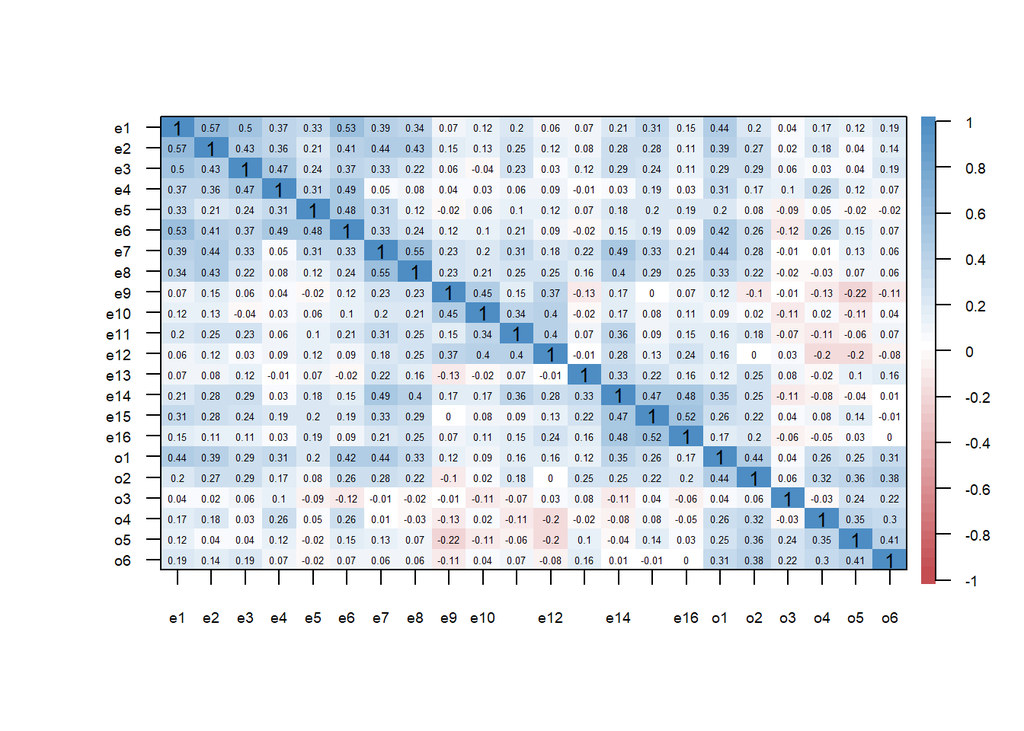

```r
### Produce FIGURE 1 - Correlation plot of ERI questionnaire
### Cor matrix
cor <- round(cor(dat.ero, method = c("pearson")),2)

### Plot the corelation matrix
# png("plot1_all.png", units = "in" , width = 8.27, height = 8.27, res = 900)
cor.plot(cor,
         main="",
         numbers=TRUE,
         pval = T,
         cuts = 0.05,
         scale = T,
         stars = F,
         cex = 0.4,
         srt = 0,
         # adjust = T,
         upper = T,
         diag = T,
         cex.axis = 0.6,
         gr = colorRampPalette(c("#B52127", "white", "#2171B5")),
         alpha = 0.8,
         show.legend = T,
)
```

```r
# dev.off()
```

In psychology and the social sciences, the magnitude of a correlation above 0.30 is considered a medium effect size. Due to relatively high correlations among many of the items, this would be a good candidate for factor analysis.

```r
### Now run FACTOR LOADING - EFA for ERO
### Try with covariance matrix
cov.mat.p.ero <- round(cov(dat.ero, method = c("pearson")),2)
cov.mat.p.ero
```

```
##       e1   e2    e3   e4    e5    e6   e7    e8    e9   e10   e11   e12   e13
## e1  0.24 0.14  0.13 0.11  0.10  0.15 0.09  0.08  0.02  0.04  0.05  0.01  0.01
## e2  0.14 0.26  0.12 0.11  0.07  0.12 0.10  0.11  0.05  0.04  0.07  0.03  0.02
## e3  0.13 0.12  0.30 0.16  0.08  0.11 0.08  0.06  0.02 -0.01  0.07  0.01  0.03
## e4  0.11 0.11  0.16 0.39  0.12  0.17 0.01  0.03  0.02  0.01  0.02  0.03  0.00
## e5  0.10 0.07  0.08 0.12  0.40  0.17 0.09  0.04 -0.01  0.02  0.03  0.04  0.02
## e6  0.15 0.12  0.11 0.17  0.17  0.32 0.09  0.07  0.04  0.03  0.06  0.02  0.00
## e7  0.09 0.10  0.08 0.01  0.09  0.09 0.21  0.12  0.07  0.05  0.07  0.04  0.04
## e8  0.08 0.11  0.06 0.03  0.04  0.07 0.12  0.23  0.07  0.06  0.06  0.06  0.03
## e9  0.02 0.05  0.02 0.02 -0.01  0.04 0.07  0.07  0.38  0.16  0.05  0.12 -0.03
## e10 0.04 0.04 -0.01 0.01  0.02  0.03 0.05  0.06  0.16  0.35  0.10  0.12 -0.01
## e11 0.05 0.07  0.07 0.02  0.03  0.06 0.07  0.06  0.05  0.10  0.27  0.11  0.02
## e12 0.01 0.03  0.01 0.03  0.04  0.02 0.04  0.06  0.12  0.12  0.11  0.27  0.00
## e13 0.01 0.02  0.03 0.00  0.02  0.00 0.04  0.03 -0.03 -0.01  0.02  0.00  0.19
## e14 0.05 0.07  0.08 0.01  0.06  0.04 0.11  0.10  0.05  0.05  0.09  0.07  0.07
## e15 0.08 0.07  0.07 0.06  0.07  0.05 0.08  0.07  0.00  0.02  0.02  0.04  0.05
## e16 0.04 0.03  0.03 0.01  0.06  0.03 0.05  0.06  0.02  0.03  0.04  0.07  0.04
## o1  0.10 0.09  0.07 0.09  0.06  0.11 0.10  0.07  0.04  0.03  0.04  0.04  0.03
## o2  0.06 0.09  0.10 0.07  0.03  0.09 0.08  0.07 -0.04  0.01  0.06  0.00  0.07
## o3  0.01 0.01  0.02 0.04 -0.04 -0.04 0.00 -0.01  0.00 -0.04 -0.02  0.01  0.02
## o4  0.05 0.05  0.01 0.09  0.02  0.08 0.00 -0.01 -0.05  0.01 -0.03 -0.06  0.00
## o5  0.03 0.01  0.01 0.04 -0.01  0.05 0.04  0.02 -0.08 -0.04 -0.02 -0.06  0.03
## o6  0.05 0.04  0.06 0.02 -0.01  0.02 0.02  0.02 -0.04  0.01  0.02 -0.02  0.04
##       e14  e15   e16   o1    o2    o3    o4    o5    o6
## e1   0.05 0.08  0.04 0.10  0.06  0.01  0.05  0.03  0.05
## e2   0.07 0.07  0.03 0.09  0.09  0.01  0.05  0.01  0.04
## e3   0.08 0.07  0.03 0.07  0.10  0.02  0.01  0.01  0.06
## e4   0.01 0.06  0.01 0.09  0.07  0.04  0.09  0.04  0.02
## e5   0.06 0.07  0.06 0.06  0.03 -0.04  0.02 -0.01 -0.01
## e6   0.04 0.05  0.03 0.11  0.09 -0.04  0.08  0.05  0.02
## e7   0.11 0.08  0.05 0.10  0.08  0.00  0.00  0.04  0.02
## e8   0.10 0.07  0.06 0.07  0.07 -0.01 -0.01  0.02  0.02
## e9   0.05 0.00  0.02 0.04 -0.04  0.00 -0.05 -0.08 -0.04
## e10  0.05 0.02  0.03 0.03  0.01 -0.04  0.01 -0.04  0.01
## e11  0.09 0.02  0.04 0.04  0.06 -0.02 -0.03 -0.02  0.02
## e12  0.07 0.04  0.07 0.04  0.00  0.01 -0.06 -0.06 -0.02
## e13  0.07 0.05  0.04 0.03  0.07  0.02  0.00  0.03  0.04
## e14  0.25 0.12  0.13 0.08  0.08 -0.04 -0.02 -0.01  0.00
## e15  0.12 0.26  0.14 0.06  0.07  0.01  0.02  0.04  0.00
## e16  0.13 0.14  0.28 0.04  0.07 -0.02 -0.01  0.01  0.00
## o1   0.08 0.06  0.04 0.22  0.13  0.01  0.07  0.07  0.08
## o2   0.08 0.07  0.07 0.13  0.40  0.02  0.11  0.14  0.14
## o3  -0.04 0.01 -0.02 0.01  0.02  0.42 -0.01  0.10  0.08
## o4  -0.02 0.02 -0.01 0.07  0.11 -0.01  0.29  0.12  0.09
## o5  -0.01 0.04  0.01 0.07  0.14  0.10  0.12  0.38  0.14
## o6   0.00 0.00  0.00 0.08  0.14  0.08  0.09  0.14  0.32
```

```r
### Calculate the eigenvalues.

# Use eigen function (apply to a covariance matrix)
cov <- cov.mat.p.ero
eigen.cov <- eigen(cov)
eigen.cov$value
```

```
##  [1] 1.43564027 0.86249892 0.58290760 0.49954270 0.42770367 0.32999787
##  [7] 0.29224662 0.28967732 0.22294746 0.21369550 0.19080028 0.17591819
## [13] 0.16293307 0.15166770 0.13454087 0.13205283 0.11323567 0.10149455
## [19] 0.09691858 0.08314699 0.07260248 0.05783085
```

```r
# Use eigen function (apply to a cor matrix)
cor <- cor.mat.p.ero
eigen.cor <- eigen(cor)
eigen.cor$value
```

```
##  [1] 5.1265719 2.6523644 1.8500018 1.5190991 1.1885138 1.0872122 1.0035168
##  [8] 0.8560609 0.7782247 0.7210238 0.6664444 0.6077483 0.5469011 0.5282330
## [15] 0.4757270 0.4457349 0.3898806 0.3846565 0.3550088 0.3115024 0.2792121
## [22] 0.2263614
```

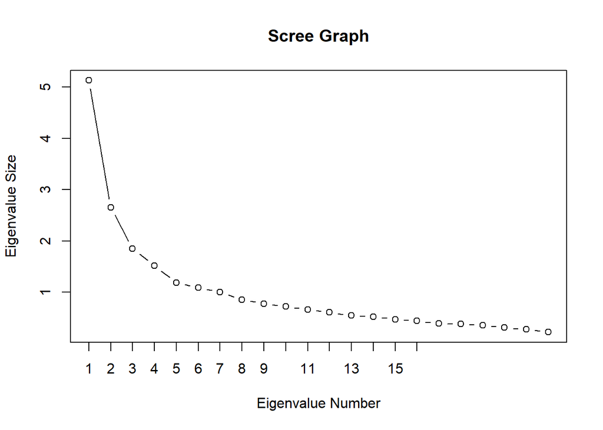

```r
# Use this command to show the plot again
# dev.cur()
# dev.off(2)

# Scree plot of cov
plot(eigen.cor$values, xlab = 'Eigenvalue Number', ylab = 'Eigenvalue Size',
     main = 'Scree Graph', type = 'b', xaxt = 'n')
axis(1, at = seq(1, 16, by = 1))
```

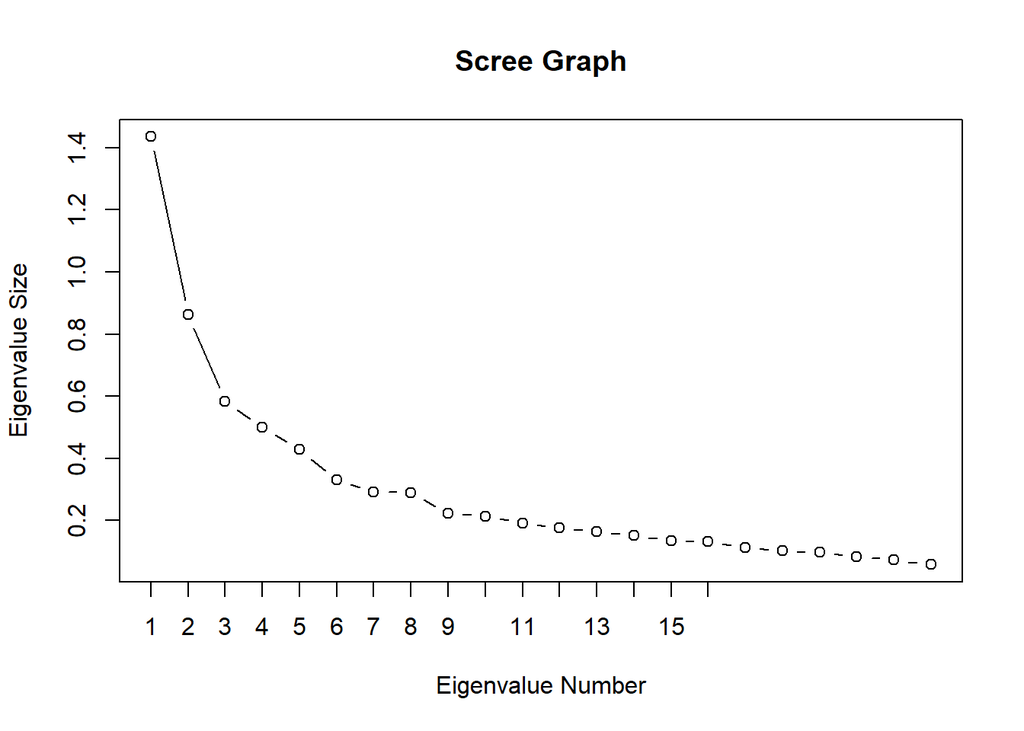

```r
# Scree plot of cor
plot(eigen.cov$values, xlab = 'Eigenvalue Number', ylab = 'Eigenvalue Size',
     main = 'Scree Graph', type = 'b', xaxt = 'n')
axis(1, at = seq(1, 16, by = 1))
```

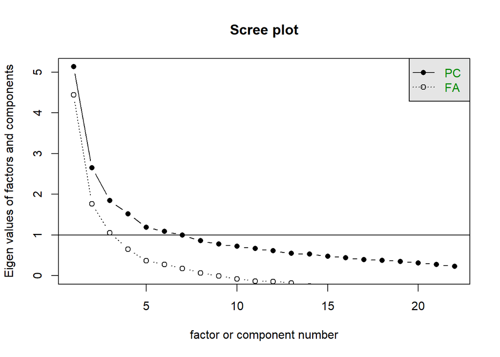

```r
# Scree plot
scree(dat.ero)
```

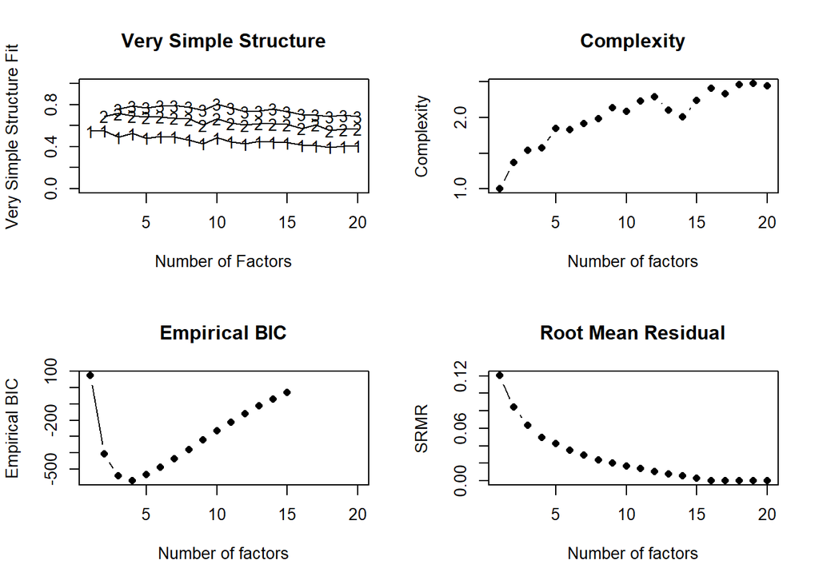

```
##
## Number of factors
## Call: vss(x = x, n = n, rotate = rotate, diagonal = diagonal, fm = fm,
##     n.obs = n.obs, plot = FALSE, title = title, use = use, cor = cor)
## VSS complexity 1 achieves a maximimum of 0.55  with  2  factors
## VSS complexity 2 achieves a maximimum of 0.72  with  3  factors
## The Velicer MAP achieves a minimum of 0.02  with  3  factors
## Empirical BIC achieves a minimum of  -571.58  with  4  factors
## Sample Size adjusted BIC achieves a minimum of  -67.09  with  8  factors
##
## Statistics by number of factors
##    vss1 vss2   map dof   chisq    prob sqresid  fit RMSEA  BIC SABIC complex
## 1  0.55 0.00 0.026 209 6.6e+02 1.3e-47    21.2 0.55 0.111 -420 241.9     1.0
## 2  0.55 0.69 0.022 188 4.7e+02 8.6e-26    14.6 0.69 0.093 -500  95.1     1.4
## 3  0.49 0.72 0.020 168 3.4e+02 2.5e-13    11.4 0.76 0.076 -528   3.5     1.5
```

[output cut: 38 more lines]

```r
###  Check number of factors
nfactors(dat.ero)
```

Note that there are very different results between selection methods. The MAP and BIC seem to have similar results in many cases.  
We decided to use MAP and BIC and also Parallel analysis as the criteria. for selecting number of factors.  
Convergence of multiple tests.  
When we have the agreement between multiple methods, it means we have higher. accuracy of the result!!!.  
Factorial Structure.  
In this case: MAP and BIC shows ERO can have 3-4 factors.

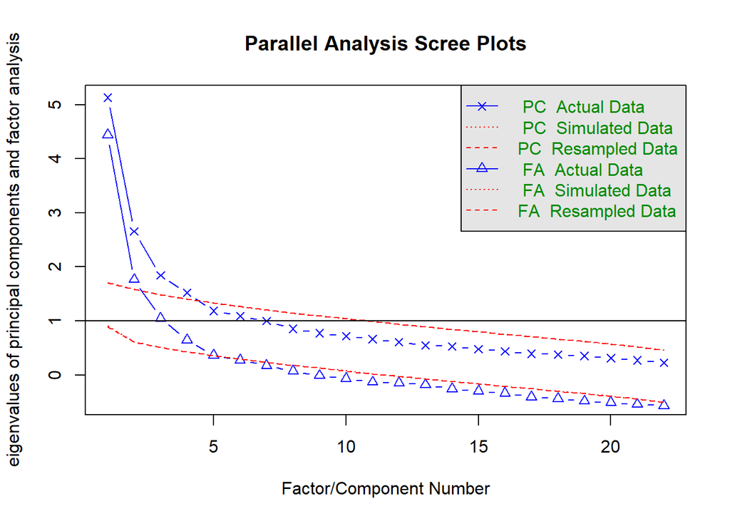

```
## Parallel analysis suggests that the number of factors =  4  and the number of components =  4
```

```r
### Parallel analysis + Another scree plot
# PA1: Use psych package
pa1 <- fa.parallel(dat.ero,
                   fm = "ml",
                   fa = "both",
                   n.iter = 400)
```